# ProcessingImages

paul

March 21, 2017

# Libraries:

- [exif library](https://cran.r-project.org/web/packages/exif/index.html)
  - Required lots of extra installations, due to not being on CRAN yet.
  - `devtools::install_github("ironholds/exif")`
  - Install “Rcpp” package is required
  - Only returns a fraction of potential metadata
- Another tool is [exifTool](http://www.sno.phy.queensu.ca/~phil/exiftool/)
  - provides runnables for windows
  - orginally a PERL library.
  - [exiftool Instructions](http://ninedegreesbelow.com/photography/exiftool-commands.html)

```r
    library(exif)
```

```r
    animal= read_exif("./TestPictures/animal1.jpg")
    lake = read_exif("./TestPictures/lake.jpg")
    # tiger = read_exif("./Test Pictures/tiger.jpg")
```

# exifTool:

- To use it, change the file name to `exiftool.exe`. Which allows the command prompt to access its’ functionalities.
- [FAQ](http://www.sno.phy.queensu.ca/~phil/exiftool/faq.html)
- Note that in orde rot use the exiftool, the current directory needs to be where the application is at.
- command used to parse the meta data into JSON format:
  - `-j` specifies that the output is in json format
  - ’-r`recusiviely go through all image files in the directory`TestPictures`
  - `exiftool -r -j TestPictures\> image.json`
- Supports various other output formats: php, html, csv etc… Refer to [exif documentations](https://cran.r-project.org/web/packages/exif/index.html) for more details.
- Reading in JSON formated data:

```r
    library(rjson)
    list = fromJSON(file="image.json")

    ## Looking at Model only
    tech = lapply(list, function(x){
                            x$Technology
                        }
                    )
    file = lapply(list,function(x){
                x$FileName
    })

    data = cbind(file = as.vector(file),
                      tech= as.vector(tech))
    data
```

```
##      file          tech
## [1,] "animal1.JPG" "Cathode Ray Tube Display"
## [2,] "lake.jpg"    "Cathode Ray Tube Display"
## [3,] "tiger.jpg"   "Cathode Ray Tube Display"
```

- Another method to do this would to select the information of interest using exif and output it to a file.

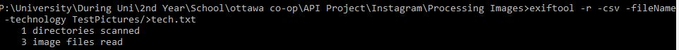

Command Prompt Command

```r
    data = read.table("tech.txt", header = TRUE, sep=",")
    data
```

```
##                 SourceFile    FileName               Technology
## 1 TestPictures/animal1.JPG animal1.JPG Cathode Ray Tube Display
## 2    TestPictures/lake.jpg    lake.jpg Cathode Ray Tube Display
## 3   TestPictures/tiger.jpg   tiger.jpg Cathode Ray Tube Display
```